# Cytotox Hg

```r
Sys.setenv(LANG = "en_US.UTF-8")

library(tidyverse)
library(drc)
```

# 1 Raw data import: ImageJ macro results file, each line is a segmented kernel, code to be modified according to image file name

```r
path <- choose.files(caption = "Choose Results file saved from ImageJ")
results <- read_csv(path)
results <- results %>% rename(nuc_id = ...1) #rename first column
```

# 2 Variable formatting

```r
# in Label, replace unwanted characters with “_”
results <- results %>% mutate(Label = str_replace_all(Label, c(" - " = "_", " " = "_")))
results
```

| nuc_id | Label | Area | Mean | StdDev | Mode | Min | Max | IntDen | RawIntDen | Slice |
| --- | --- | --- | --- | --- | --- | --- | --- | --- | --- | --- |
| 1 | Hg_0.1_uM_A_220216_10_w1Fluo_GFP_quad_single.TIF_bgd_substracted.tif | 195.6175 | 254.4492 | 11.850855 | 255 | 0 | 255 | 49774.725 | 117810 | 1 |
| 2 | Hg_0.1_uM_A_220216_10_w1Fluo_GFP_quad_single.TIF_bgd_substracted.tif | 35.4900 | 255.0000 | 0.000000 | 255 | 255 | 255 | 9049.950 | 21420 | 1 |
| 3 | Hg_0.1_uM_A_220216_10_w1Fluo_GFP_quad_single.TIF_bgd_substracted.tif | 59.9950 | 255.0000 | 0.000000 | 255 | 255 | 255 | 15298.725 | 36210 | 1 |
| 4 | Hg_0.1_uM_A_220216_10_w1Fluo_GFP_quad_single.TIF_bgd_substracted.tif | 113.6525 | 255.0000 | 0.000000 | 255 | 255 | 255 | 28981.388 | 68595 | 1 |
| 5 | Hg_0.1_uM_A_220216_10_w1Fluo_GFP_quad_single.TIF_bgd_substracted.tif | 13.0975 | 255.0000 | 0.000000 | 255 | 255 | 255 | 3339.863 | 7905 | 1 |
| 6 | Hg_0.1_uM_A_220216_10_w1Fluo_GFP_quad_single.TIF_bgd_substracted.tif | 14.3650 | 255.0000 | 0.000000 | 255 | 255 | 255 | 3663.075 | 8670 | 1 |
| 7 | Hg_0.1_uM_A_220216_10_w1Fluo_GFP_quad_single.TIF_bgd_substracted.tif | 12.6750 | 255.0000 | 0.000000 | 255 | 255 | 255 | 3232.125 | 7650 | 1 |
| 8 | Hg_0.1_uM_A_220216_10_w1Fluo_GFP_quad_single.TIF_bgd_substracted.tif | 48.1650 | 255.0000 | 0.000000 | 255 | 255 | 255 | 12282.075 | 29070 | 1 |
| 9 | Hg_0.1_uM_A_220216_10_w1Fluo_GFP_quad_single.TIF_bgd_substracted.tif | 47.7425 | 255.0000 | 0.000000 | 255 | 255 | 255 | 12174.337 | 28815 | 1 |
| 10 | Hg_0.1_uM_A_220216_10_w1Fluo_GFP_quad_single.TIF_bgd_substracted.tif | 10.5625 | 255.0000 | 0.000000 | 255 | 255 | 255 | 2693.438 | 6375 | 1 |

[output cut: 990 more lines]

```r
# Separation of the "label" information into individual variables
results <- results %>% separate(Label, sep ="_", into = c("metal", "conc", "unit", "replicate", "date", "image_id", "wave", "chan")) %>% mutate(conc = as.numeric(conc), image_id = as.numeric(image_id))
results
```

| nuc_id | metal | conc | unit | replicate | date | image_id | wave | chan | Area | Mean | StdDev | Mode | Min | Max | IntDen | RawIntDen | Slice |
| --- | --- | --- | --- | --- | --- | --- | --- | --- | --- | --- | --- | --- | --- | --- | --- | --- | --- |
| 1 | Hg | 0.1 | uM | A | 220216 | 10 | w1Fluo | GFP | 195.6175 | 254.4492 | 11.850855 | 255 | 0 | 255 | 49774.725 | 117810 | 1 |
| 2 | Hg | 0.1 | uM | A | 220216 | 10 | w1Fluo | GFP | 35.4900 | 255.0000 | 0.000000 | 255 | 255 | 255 | 9049.950 | 21420 | 1 |
| 3 | Hg | 0.1 | uM | A | 220216 | 10 | w1Fluo | GFP | 59.9950 | 255.0000 | 0.000000 | 255 | 255 | 255 | 15298.725 | 36210 | 1 |
| 4 | Hg | 0.1 | uM | A | 220216 | 10 | w1Fluo | GFP | 113.6525 | 255.0000 | 0.000000 | 255 | 255 | 255 | 28981.388 | 68595 | 1 |
| 5 | Hg | 0.1 | uM | A | 220216 | 10 | w1Fluo | GFP | 13.0975 | 255.0000 | 0.000000 | 255 | 255 | 255 | 3339.863 | 7905 | 1 |
| 6 | Hg | 0.1 | uM | A | 220216 | 10 | w1Fluo | GFP | 14.3650 | 255.0000 | 0.000000 | 255 | 255 | 255 | 3663.075 | 8670 | 1 |
| 7 | Hg | 0.1 | uM | A | 220216 | 10 | w1Fluo | GFP | 12.6750 | 255.0000 | 0.000000 | 255 | 255 | 255 | 3232.125 | 7650 | 1 |
| 8 | Hg | 0.1 | uM | A | 220216 | 10 | w1Fluo | GFP | 48.1650 | 255.0000 | 0.000000 | 255 | 255 | 255 | 12282.075 | 29070 | 1 |
| 9 | Hg | 0.1 | uM | A | 220216 | 10 | w1Fluo | GFP | 47.7425 | 255.0000 | 0.000000 | 255 | 255 | 255 | 12174.337 | 28815 | 1 |
| 10 | Hg | 0.1 | uM | A | 220216 | 10 | w1Fluo | GFP | 10.5625 | 255.0000 | 0.000000 | 255 | 255 | 255 | 2693.438 | 6375 | 1 |

[output cut: 990 more lines]

```r
## Adds dish identifier to each line
results <- results %>% mutate(dish = "")
cytox <- results %>% mutate(dish = ifelse(replicate == "A" & conc > 5, "D1", dish)) %>% mutate(dish = ifelse(replicate == "A" & conc < 50, "D2", dish)) %>% mutate(dish = ifelse(replicate == "B" & conc > 5, "D3", dish)) %>% mutate(dish = ifelse(replicate == "B" & conc < 50, "D4", dish)) %>% mutate(dish = ifelse(replicate == "C" & conc > 5, "D5", dish)) %>% mutate(dish = ifelse(replicate == "C" & conc < 50, "D6", dish))
cytox
```

| nuc_id | metal | conc | unit | replicate | date | image_id | wave | chan | Area | Mean | StdDev | Mode | Min | Max | IntDen | RawIntDen | Slice | dish |
| --- | --- | --- | --- | --- | --- | --- | --- | --- | --- | --- | --- | --- | --- | --- | --- | --- | --- | --- |
| 1 | Hg | 0.1 | uM | A | 220216 | 10 | w1Fluo | GFP | 195.6175 | 254.4492 | 11.850855 | 255 | 0 | 255 | 49774.725 | 117810 | 1 | D2 |
| 2 | Hg | 0.1 | uM | A | 220216 | 10 | w1Fluo | GFP | 35.4900 | 255.0000 | 0.000000 | 255 | 255 | 255 | 9049.950 | 21420 | 1 | D2 |
| 3 | Hg | 0.1 | uM | A | 220216 | 10 | w1Fluo | GFP | 59.9950 | 255.0000 | 0.000000 | 255 | 255 | 255 | 15298.725 | 36210 | 1 | D2 |
| 4 | Hg | 0.1 | uM | A | 220216 | 10 | w1Fluo | GFP | 113.6525 | 255.0000 | 0.000000 | 255 | 255 | 255 | 28981.388 | 68595 | 1 | D2 |
| 5 | Hg | 0.1 | uM | A | 220216 | 10 | w1Fluo | GFP | 13.0975 | 255.0000 | 0.000000 | 255 | 255 | 255 | 3339.863 | 7905 | 1 | D2 |
| 6 | Hg | 0.1 | uM | A | 220216 | 10 | w1Fluo | GFP | 14.3650 | 255.0000 | 0.000000 | 255 | 255 | 255 | 3663.075 | 8670 | 1 | D2 |
| 7 | Hg | 0.1 | uM | A | 220216 | 10 | w1Fluo | GFP | 12.6750 | 255.0000 | 0.000000 | 255 | 255 | 255 | 3232.125 | 7650 | 1 | D2 |
| 8 | Hg | 0.1 | uM | A | 220216 | 10 | w1Fluo | GFP | 48.1650 | 255.0000 | 0.000000 | 255 | 255 | 255 | 12282.075 | 29070 | 1 | D2 |
| 9 | Hg | 0.1 | uM | A | 220216 | 10 | w1Fluo | GFP | 47.7425 | 255.0000 | 0.000000 | 255 | 255 | 255 | 12174.337 | 28815 | 1 | D2 |
| 10 | Hg | 0.1 | uM | A | 220216 | 10 | w1Fluo | GFP | 10.5625 | 255.0000 | 0.000000 | 255 | 255 | 255 | 2693.438 | 6375 | 1 | D2 |

[output cut: 990 more lines]

```r
# Verification of addition (summary)
cytox %>% count(dish, replicate, conc)
```

| dish | replicate | conc | n |
| --- | --- | --- | --- |
| D1 | A | 50.0 | 5120 |
| D1 | A | 100.0 | 3360 |
| D1 | A | 200.0 | 5803 |
| D1 | A | 500.0 | 3833 |
| D2 | A | 0.0 | 2550 |
| D2 | A | 0.1 | 2561 |
| D2 | A | 1.0 | 3967 |
| D2 | A | 5.0 | 2860 |
| D3 | B | 50.0 | 2040 |
| D3 | B | 100.0 | 6294 |

[output cut: 14 more lines]

# 3 List of all measured nuclei: cytox table saved as .csv file

```r
write.csv(cytox, file = "all_measured_nuclei_cytox_R.csv")
```

# 4 ———–

# 5 Nuclei area by concentration and channel

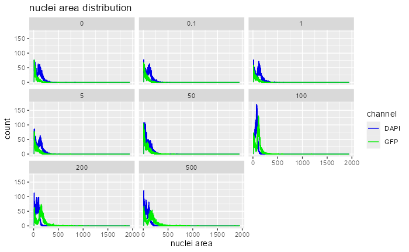

```r
p0 <- ggplot(cytox, aes(Area)) +
  geom_freqpoly(aes(color = chan), binwidth = 1) +
  facet_wrap(~conc) + scale_color_manual(name = "channel", values = c("blue2", "green2")) +
  labs(title = "nuclei area distribution", x = "nuclei area")
p0
ggsave("p0_nuclei_area_per_concentration_channel.pdf", plot = p0, device = "pdf", width = 7, height = 5, unit="in")
```

# 6 Nuclei area in DAPI for each coverslip

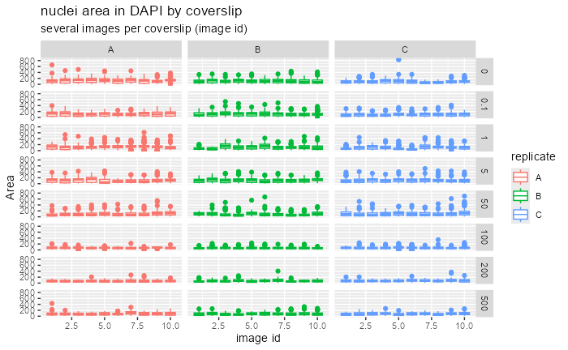

```r
p1 <- ggplot(filter(cytox, chan == "DAPI")) +
  geom_boxplot(aes(group = image_id, image_id, Area, color = replicate)) +
  facet_grid(conc ~ replicate) + labs(title = "nuclei area in DAPI by coverslip", subtitle = "several images per coverslip (image id)", x = "image id")
p1
ggsave("p1_nuclei_area_DAPI_par_coverslip.pdf", plot = p1, device = "pdf", width = 7, height = 5, unit="in")
```

# 7 Nuclei area in GFP for each coverslip

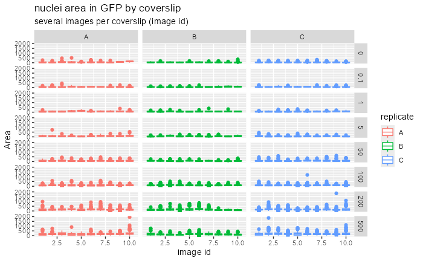

```r
p2 <- ggplot(filter(cytox, chan == "GFP")) +
  geom_boxplot(aes(group = image_id, image_id, Area, color = replicate)) +
  facet_grid(conc ~ replicate) + labs(title = "nuclei area in GFP by coverslip", subtitle = "several images per coverslip (image id)", x = "image id")
p2
ggsave("p2_nuclei_area_GFP_per_coverslip.pdf", plot = p2, device = "pdf", width = 7, height = 5, unit="in")
```

# 8 ———–

# 9 Data analysis, data tydying with nuclei number per individual image

```r
# counts the number of nuclei per image and channel
nuc_count_list <- cytox %>% group_by(conc, image_id, replicate, dish, chan) %>% summarise(nuclei = n())
nuc_count_list
```

| conc | image_id | replicate | dish | chan | nuclei |
| --- | --- | --- | --- | --- | --- |
| 0.0 | 1 | A | D2 | DAPI | 207 |
| 0.0 | 1 | A | D2 | GFP | 52 |
| 0.0 | 1 | B | D4 | DAPI | 109 |
| 0.0 | 1 | B | D4 | GFP | 48 |
| 0.0 | 1 | C | D6 | DAPI | 283 |
| 0.0 | 1 | C | D6 | GFP | 106 |
| 0.0 | 2 | A | D2 | DAPI | 192 |
| 0.0 | 2 | A | D2 | GFP | 51 |
| 0.0 | 2 | B | D4 | DAPI | 224 |
| 0.0 | 2 | B | D4 | GFP | 86 |

[output cut: 470 more lines]

```r
# creates a tibble with the number of DAPI and GFP nuclei for each image
nuc_count <- pivot_wider(nuc_count_list, names_from = chan, values_from = nuclei)
nuc_count
```

| conc | image_id | replicate | dish | DAPI | GFP |
| --- | --- | --- | --- | --- | --- |
| 0.0 | 1 | A | D2 | 207 | 52 |
| 0.0 | 1 | B | D4 | 109 | 48 |
| 0.0 | 1 | C | D6 | 283 | 106 |
| 0.0 | 2 | A | D2 | 192 | 51 |
| 0.0 | 2 | B | D4 | 224 | 86 |
| 0.0 | 2 | C | D6 | 296 | 122 |
| 0.0 | 3 | A | D2 | 194 | 58 |
| 0.0 | 3 | B | D4 | 205 | 111 |
| 0.0 | 3 | C | D6 | 374 | 155 |
| 0.0 | 4 | A | D2 | 119 | 35 |

[output cut: 230 more lines]

# 10 Data analysis, calculation of mortality and viability in individual images

```r
# computes viability and mortality based on the number of GFP(=dead) and DAPI(=dead+alive) values
res_all <- nuc_count %>% mutate(mortality = GFP/DAPI, viability = 1 - (GFP/DAPI)) %>% rownames_to_column(var = "uniq_id")
res_all
```

| uniq_id | conc | image_id | replicate | dish | DAPI | GFP | mortality | viability |
| --- | --- | --- | --- | --- | --- | --- | --- | --- |
| 1 | 0.0 | 1 | A | D2 | 207 | 52 | 0.2512077 | 0.748792271 |
| 2 | 0.0 | 1 | B | D4 | 109 | 48 | 0.4403670 | 0.559633028 |
| 3 | 0.0 | 1 | C | D6 | 283 | 106 | 0.3745583 | 0.625441696 |
| 4 | 0.0 | 2 | A | D2 | 192 | 51 | 0.2656250 | 0.734375000 |
| 5 | 0.0 | 2 | B | D4 | 224 | 86 | 0.3839286 | 0.616071429 |
| 6 | 0.0 | 2 | C | D6 | 296 | 122 | 0.4121622 | 0.587837838 |
| 7 | 0.0 | 3 | A | D2 | 194 | 58 | 0.2989691 | 0.701030928 |
| 8 | 0.0 | 3 | B | D4 | 205 | 111 | 0.5414634 | 0.458536585 |
| 9 | 0.0 | 3 | C | D6 | 374 | 155 | 0.4144385 | 0.585561497 |
| 10 | 0.0 | 4 | A | D2 | 119 | 35 | 0.2941176 | 0.705882353 |

[output cut: 230 more lines]

```r
write.csv(res_all, file = "all_viability_values_R.csv")
```

## 10.1 Data analysis, nuclei count per image

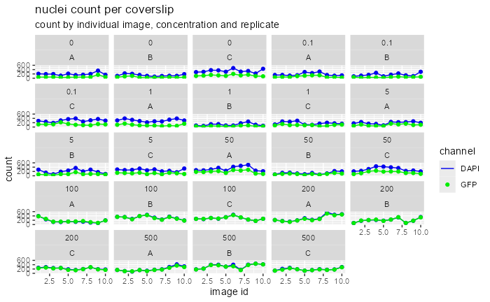

```r
p3 <- ggplot(res_all) +
  geom_line(aes(image_id, DAPI, color = "DAPI")) +
  geom_point(aes(image_id, DAPI, color = "DAPI"), color = "blue2") +
  geom_line(aes(image_id, GFP, color = "GFP"), color = "green2") +
  geom_point(aes(image_id, GFP, color = "GFP")) +
  scale_color_manual(name = "channel", values = c("blue2", "green2")) +
  labs(title = "nuclei count per coverslip", subtitle = "count by individual image, concentration and replicate", y = "count", x = "image id") +
  facet_wrap(conc~replicate)
p3
ggsave("p3_nuclei_count_percoverslip.pdf", plot = p3, device = "pdf", width = 7, height = 5, unit="in")
```

## 10.2 Data analysis, viability per image

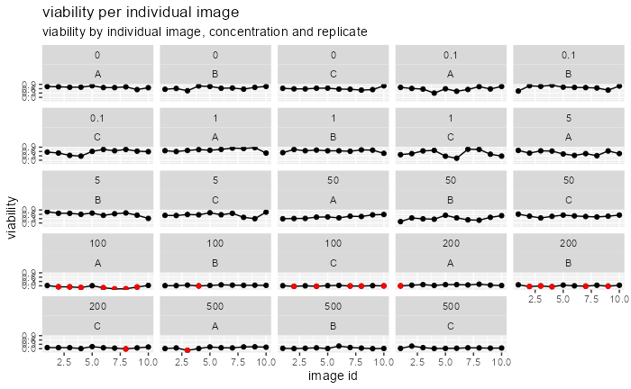

```r
p4 <- ggplot(res_all, aes(image_id, viability) ) +
  geom_line() +
  geom_point() +
  geom_point(data = filter(res_all, viability <0), aes(image_id, viability), color = "red") +
  facet_wrap(conc~replicate) +
  labs(title = "viability per individual image", subtitle = "viability by individual image, concentration and replicate", y = "viability", x = "image id")
p4
ggsave("p4_viability_individual_image.pdf", plot = p4, device = "pdf", width = 7, height = 5, unit="in")
```

## 10.3 Data analysis of dishes, new table with dish data

```r
res_all_dish <- res_all %>% group_by(dish, conc) %>% summarise(DAPI = sum(DAPI), GFP = sum(GFP), viability = mean(viability))
res_all_dish
```

| dish | conc | DAPI | GFP | viability |
| --- | --- | --- | --- | --- |
| D1 | 50.0 | 3231 | 1889 | 0.417623284 |
| D1 | 100.0 | 1632 | 1728 | -0.084532363 |
| D1 | 200.0 | 2989 | 2814 | 0.054715352 |
| D1 | 500.0 | 1991 | 1842 | 0.051035075 |
| D2 | 0.0 | 1943 | 607 | 0.698031054 |
| D2 | 0.1 | 1793 | 768 | 0.581522037 |
| D2 | 1.0 | 3077 | 890 | 0.710554407 |
| D2 | 5.0 | 1905 | 955 | 0.506248451 |
| D3 | 50.0 | 1234 | 806 | 0.319134720 |
| D3 | 100.0 | 3193 | 3101 | 0.031254228 |

[output cut: 14 more lines]

```r
check_nuclei_number <- sum(res_all_dish$DAPI)+sum(res_all_dish$GFP)
cat(c("total nuclei count (check) =", check_nuclei_number))
```

```
total nuclei count (check) = 90919
```

# 11 ———–

# 12 DAPI nuclei count by dish

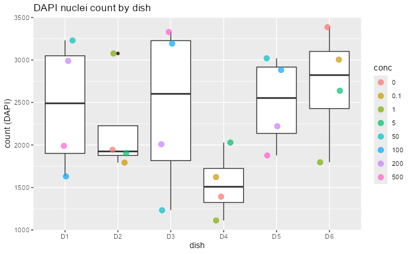

```r
ggplot(res_all_dish) +
  geom_boxplot(aes(dish, DAPI)) +
  geom_jitter(aes(dish, DAPI, color = factor(conc)), size = 3, alpha = 0.7, width = 0.2) +
  labs(title = "DAPI nuclei count by dish", y ="count (DAPI)") +
  scale_color_discrete(name = "conc")
```

# 13 GFP nuclei count by dish

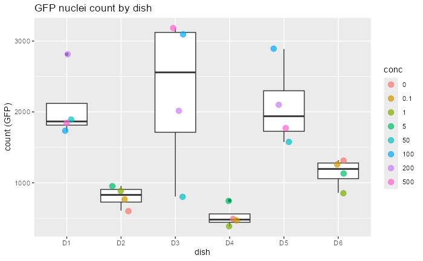

```r
ggplot(res_all_dish) +
  geom_boxplot(aes(dish, GFP)) +
  geom_jitter(aes(dish, GFP, color = factor(conc)), size = 3, alpha = 0.7, width = 0.2) +
  labs(title = "GFP nuclei count by dish", y ="count (GFP)") +
  scale_color_discrete(name = "conc")
```

# 14 Viability by dish

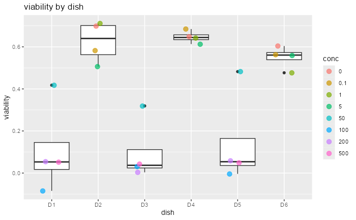

```r
ggplot(res_all_dish) +
  geom_boxplot(aes(dish, viability)) +
  geom_jitter(aes(dish, viability, color = factor(conc)), size = 3, alpha = 0.7, width = 0.2) +
  labs(title = "viability by dish") +
  scale_color_discrete(name = "conc")
```

# 15 ———–

# 16 ‘Abnormal’ images with negative viability: discard or set viability to 0 if high concentration

Several images have viability<0 and correspond to high Hg concentrations, set these viability values to 0

```r
# Selects only images with negative viability
res_discarded <- filter(res_all, viability <0)
res_discarded
```

| uniq_id | conc | image_id | replicate | dish | DAPI | GFP | mortality | viability |
| --- | --- | --- | --- | --- | --- | --- | --- | --- |
| 154 | 100 | 2 | A | D1 | 245 | 262 | 1.069388 | -0.069387755 |
| 156 | 100 | 2 | C | D5 | 252 | 261 | 1.035714 | -0.035714286 |
| 157 | 100 | 3 | A | D1 | 122 | 131 | 1.073770 | -0.073770492 |
| 160 | 100 | 4 | A | D1 | 118 | 132 | 1.118644 | -0.118644068 |
| 161 | 100 | 4 | B | D3 | 390 | 393 | 1.007692 | -0.007692308 |
| 162 | 100 | 4 | C | D5 | 271 | 279 | 1.029520 | -0.029520295 |
| 166 | 100 | 6 | A | D1 | 126 | 143 | 1.134921 | -0.134920635 |
| 169 | 100 | 7 | A | D1 | 132 | 160 | 1.212121 | -0.212121212 |
| 171 | 100 | 7 | C | D5 | 328 | 332 | 1.012195 | -0.012195122 |
| 172 | 100 | 8 | A | D1 | 92 | 111 | 1.206522 | -0.206521739 |

[output cut: 11 more lines]

```r
# Change negative viability values to 0 in this specific case
res_all <- res_all %>% mutate(viability =ifelse(viability<0, 0, viability))
```

# 17 Data analysis, viability by coverslip and replicate

## 17.1 The coverslip 1µM replicate C is different from the other two replicates, to be taken out of the analysis!

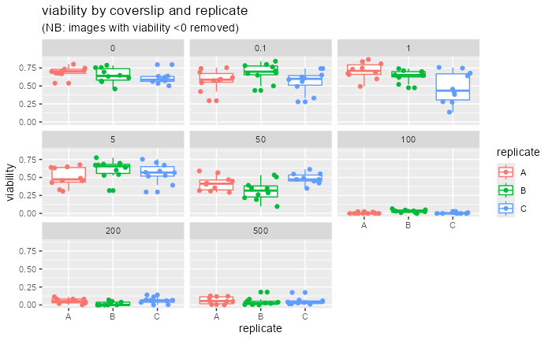

```r
# boxplot of viability
p5 <- ggplot(res_all) +
  geom_boxplot(aes(replicate, viability, color = replicate)) +
  geom_jitter(aes(replicate, viability, color = replicate)) +
  facet_wrap(~conc) +
  labs(title = "viability by coverslip and replicate", subtitle = "(NB: images with viability <0 removed)", y = "viability")
p5
ggsave("p5_viability_coverslip_and_replicate.pdf", plot = p5, device = "pdf", width = 7, height = 5, unit="in")
```

## 17.2 Data suppression @ 1µM replicate C

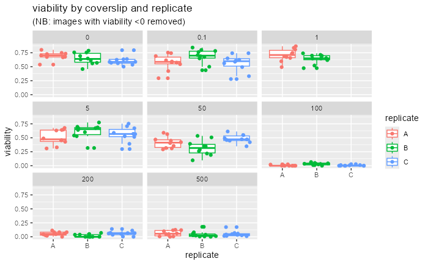

```r
res_all_filtered <- res_all %>% filter (!(conc == 1 & replicate == "C"))

write.csv(res_all_filtered, file = "all_viability_filtered_values_R.csv")

ggplot(res_all_filtered) +
  geom_boxplot(aes(replicate, viability, color = replicate)) +
  geom_jitter(aes(replicate, viability, color = replicate)) +
  facet_wrap(~conc) +
  labs(title = "viability by coverslip and replicate", subtitle = "(NB: images with viability <0 removed)", y = "viability")
```

# 18 Calculation of the total number of analyzed and selected cells

```r
n_cells <- res_all_filtered %>% group_by() %>% summarise(total = sum (DAPI))
n_cells
```

| total |
| --- |
| 53519 |

# 19 ————

# 20 Summary table of results

```r
mean_viab_conc <- res_all_filtered %>% group_by(conc) %>% summarise(mean_viability = mean(viability), sd = sd(viability), median_viability = median(viability), n_DAPI = sum(DAPI), n_GFP= sum(GFP), n_images = n())
viab_0 <- filter(mean_viab_conc, conc == 0)$mean_viability
mean_viab_conc <- mean_viab_conc %>% mutate(relative_viability = mean_viability/viab_0)
mean_viab_conc
```

| conc | mean_viability | sd | median_viability | n_DAPI | n_GFP | n_images | relative_viability |
| --- | --- | --- | --- | --- | --- | --- | --- |
| 0.0 | 0.64987046 | 0.09126833 | 0.642746401 | 6724 | 2424 | 30 | 1.00000000 |
| 0.1 | 0.60955872 | 0.14771202 | 0.620109182 | 6421 | 2495 | 30 | 0.93796958 |
| 1.0 | 0.67588055 | 0.10387815 | 0.681044053 | 4189 | 1272 | 20 | 1.04002350 |
| 5.0 | 0.55957128 | 0.13627981 | 0.579590620 | 6572 | 2829 | 30 | 0.86105049 |
| 50.0 | 0.40634029 | 0.12452834 | 0.421288648 | 7485 | 4270 | 30 | 0.62526352 |
| 100.0 | 0.01444043 | 0.01861565 | 0.007370707 | 7707 | 7716 | 30 | 0.02222048 |
| 200.0 | 0.04506308 | 0.03890871 | 0.044520271 | 7222 | 6931 | 30 | 0.06934163 |
| 500.0 | 0.05154183 | 0.04949446 | 0.039251187 | 7199 | 6806 | 30 | 0.07931093 |

```r
write.csv(mean_viab_conc, file="summary_table_results_R.csv")
```

# 21 Summary table of results grouped by concentration and replicate

```r
mean_viab_conc_replicate <- res_all_filtered %>% group_by(conc, replicate) %>% summarise(mean_viability = mean(viability), sd = sd(viability), median_viability = median(viability), n_DAPI = sum(DAPI), n_GFP= sum(GFP), n_images = n())
# Calculation of normalized viability for each replicate (= absolute (raw) viability / mean viability of 3 replicates at 0 µM)
mean_viab_conc_replicate <- mean_viab_conc_replicate %>% mutate(relative_viability = 0)

mean_viab_conc_replicate <- mean_viab_conc_replicate %>% mutate(relative_viability = mean_viability/viab_0)

mean_viab_conc_replicate
```

| conc | replicate | mean_viability | sd | median_viability | n_DAPI | n_GFP | n_images | relative_viability |
| --- | --- | --- | --- | --- | --- | --- | --- | --- |
| 0.0 | A | 0.698031054 | 0.069168603 | 0.70345664 | 1943 | 607 | 10 | 1.074107986 |
| 0.0 | B | 0.647746354 | 0.103336537 | 0.63959900 | 1394 | 498 | 10 | 0.996731490 |
| 0.0 | C | 0.603833979 | 0.080256237 | 0.58669967 | 3387 | 1319 | 10 | 0.929160524 |
| 0.1 | A | 0.581522037 | 0.140684509 | 0.58747329 | 1793 | 768 | 10 | 0.894827616 |
| 0.1 | B | 0.684735638 | 0.129510770 | 0.69844478 | 1623 | 462 | 10 | 1.053649424 |
| 0.1 | C | 0.562418497 | 0.155299568 | 0.59902484 | 3005 | 1265 | 10 | 0.865431697 |
| 1.0 | A | 0.710554407 | 0.113993415 | 0.71012808 | 3077 | 890 | 10 | 1.093378524 |
| 1.0 | B | 0.641206694 | 0.084345008 | 0.65086674 | 1112 | 382 | 10 | 0.986668468 |
| 5.0 | A | 0.506248451 | 0.134888413 | 0.47274661 | 1905 | 955 | 10 | 0.778999017 |
| 5.0 | B | 0.613179431 | 0.127336349 | 0.65571429 | 2028 | 749 | 10 | 0.943541008 |

[output cut: 13 more lines]

```r
write.csv(mean_viab_conc_replicate, file="summary_table_results_filtered_replicate_R.csv")
```

# 22 Summary viability plot

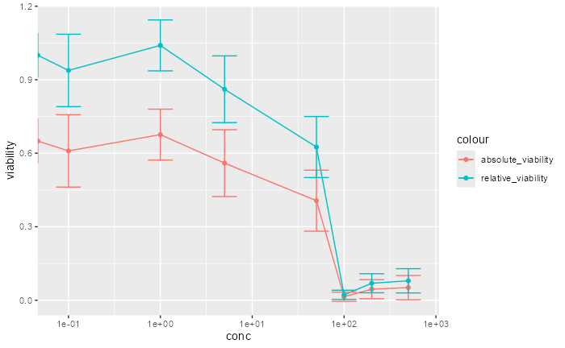

```r
p6 <- ggplot(mean_viab_conc) +
  geom_point(aes(conc, mean_viability, color = "absolute_viability")) +
  geom_line(aes(conc, mean_viability, color = "absolute_viability")) +
  geom_point(aes(conc, relative_viability, color = "relative_viability")) +
  geom_line(aes(conc, relative_viability, color = "relative_viability")) +
  geom_errorbar(aes(x= conc, y = mean_viability, ymin=mean_viability-sd, ymax = mean_viability+sd, color = "absolute_viability")) +
  geom_errorbar(aes(x= conc, y = relative_viability, ymin=relative_viability-sd, ymax = relative_viability+sd, color = "relative_viability")) +
  labs(y="viability") +
  scale_x_log10()
p6
ggsave("p6_summary_viability_plot.pdf", plot = p6, device = "pdf", width = 7, height = 5, unit="in")
```

# 23 Summary viability table and plot grouped by replicate

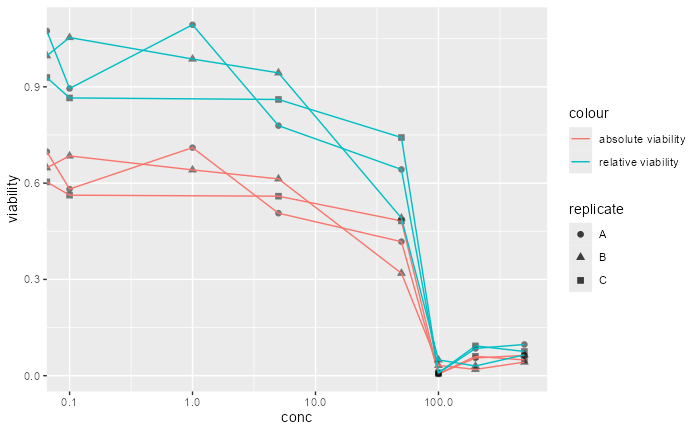

```r
p7 <- ggplot(mean_viab_conc_replicate) +
  geom_point(aes(conc, mean_viability, shape = replicate), color= "black", size = 2, alpha = 0.5) +
  geom_line(aes(group = replicate, conc, mean_viability, color = "absolute viability")) +
  geom_point(aes(conc, relative_viability, shape = replicate), color= "black", size = 2, alpha = 0.5) +
  geom_line(aes(group = replicate, conc, relative_viability, color = "relative viability")) +
  scale_x_log10() +
  ylab("viability")
p7
ggsave("p7_summary_viability_plot_by_replicate.pdf", plot = p7, device = "pdf", width = 7, height = 5, unit="in")
```

# 24 ———-

# 25 Dose-response curves and fit for normalized viability

## 25.1 Comparison of the three models LL4, W14 and W24 for the dose-response function fit

Use only 4-parameter fits without constraining either Lower limit or Upper limit. The best-fitting model is the one with the lowest IC value in the comparison test.

```r
model.LL4<- drm(relative_viability~conc, data=mean_viab_conc_replicate, fct=LL.4(fixed=c(NA, NA, NA, NA), names = c("Slope", "Lower Limit", "Upper Limit", "ED50")))

mselect(model.LL4, fctList = list(W1.4(fixed=c(NA, NA, NA, NA)), W2.4(fixed=c(NA, NA, NA, NA))),linreg=TRUE)
```

```
         logLik        IC Lack of fit     Res var
LL.4  26.067538 -42.13508   0.1039672 0.007346257
W1.4  26.066672 -42.13334   0.1039178 0.007346811
W2.4  26.020724 -42.04145   0.1013311 0.007376224
Cubic 19.183563 -28.36713          NA 0.013367115
Quad  12.560765 -17.12153          NA 0.022587569
Lin   -4.305634  14.61127          NA 0.093247103
```

## 25.2 Plot for models LL4, W14 and W24

```r
model.LL4 <-  drm(relative_viability~conc, data=mean_viab_conc_replicate, fct=LL.4(fixed=c(NA, NA, NA, NA), names = c("Slope", "Lower Limit", "Upper Limit", "ED50")))

model.W14 <-  drm(relative_viability~conc, data=mean_viab_conc_replicate, fct=W1.4(fixed=c(NA, NA, NA, NA), names = c("Slope", "Lower Limit", "Upper Limit", "ED50")))

model.W24 <-  drm(relative_viability~conc, data=mean_viab_conc_replicate, fct=W2.4(fixed=c(NA, NA, NA, NA), names = c("Slope", "Lower Limit", "Upper Limit", "ED50")))


plot(model.LL4, broken = TRUE, xlab="Concentration (µM), LL4(black), W14(red), W24(green) ", ylab="relative viability", type='all',lty=1, lwd=2,)

plot(model.W14, add = TRUE, col="red2",lty=2, lwd=2)
```

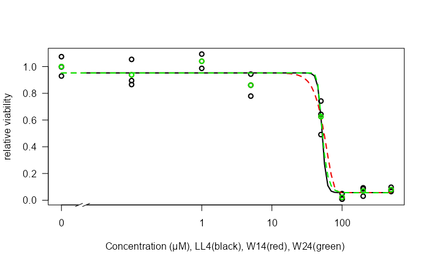

```r
plot(model.W24, add = TRUE, col="green2",lty=2, lwd=2)
```

## 25.3 Summary of LL4, W14 and W24 model parameters

```r
summary(model.LL4)
```

```
Model fitted: Log-logistic (ED50 as parameter) (4 parms)

Parameter estimates:

                         Estimate Std. Error t-value   p-value
Slope:(Intercept)       14.706218  50.490051  0.2913   0.77400
Lower Limit:(Intercept)  0.056940   0.028578  1.9924   0.06089 .
Upper Limit:(Intercept)  0.952464   0.025843 36.8563 < 2.2e-16 ***
ED50:(Intercept)        51.912878   6.750620  7.6901 2.999e-07 ***
---
Signif. codes:  0 ‘***’ 0.001 ‘**’ 0.01 ‘*’ 0.05 ‘.’ 0.1 ‘ ’ 1

Residual standard error:

 0.08571031 (19 degrees of freedom)
```

```r
summary(model.W14)
```

```
Model fitted: Weibull (type 1) (4 parms)

Parameter estimates:

                         Estimate Std. Error t-value   p-value
Slope:(Intercept)        4.235878   3.762849  1.1257   0.27431
Lower Limit:(Intercept)  0.057076   0.028598  1.9958   0.06049 .
Upper Limit:(Intercept)  0.952495   0.025845 36.8541 < 2.2e-16 ***
ED50:(Intercept)        60.208388  10.137712  5.9391 1.022e-05 ***
---
Signif. codes:  0 ‘***’ 0.001 ‘**’ 0.01 ‘*’ 0.05 ‘.’ 0.1 ‘ ’ 1

Residual standard error:

 0.08571354 (19 degrees of freedom)
```

```r
summary(model.W24)
```

```
Model fitted: Weibull (type 2) (4 parms)

Parameter estimates:

                         Estimate Std. Error t-value p-value
Slope:(Intercept)       -8.372977   7.028907 -1.1912 0.24824
Lower Limit:(Intercept)  0.055996   0.028976  1.9325 0.06835 .
Upper Limit:(Intercept)  0.952380   0.025896 36.7774 < 2e-16 ***
ED50:(Intercept)        50.048156   0.967225 51.7441 < 2e-16 ***
---
Signif. codes:  0 ‘***’ 0.001 ‘**’ 0.01 ‘*’ 0.05 ‘.’ 0.1 ‘ ’ 1

Residual standard error:

 0.08588494 (19 degrees of freedom)
```

```r
# Saves the output to a text file
capture.output(summary(model.LL4), summary(model.W14), summary(model.W24), file = "Models_summary_R.txt")
```

## 25.4 Calculation of IC10 and IC50 on models LL4, W14 and W24

```r
IC_LL4 <- as_tibble(ED(model.LL4, c(10, 20, 50), interval="delta"), rownames = NA) %>% rownames_to_column(var = "IC") %>% separate(IC, sep=":", into=c("A", "B", "IC")) %>% dplyr::select(-A, -B) %>% mutate(IC = as.numeric(IC), model = "LL4") %>% relocate(model)
```

```
Estimated effective doses

       Estimate Std. Error   Lower   Upper
e:1:10  44.7083    17.1895  8.7302 80.6864
e:1:20  47.2428     9.2382 27.9070 66.5787
e:1:50  51.9129     6.7506 37.7837 66.0421
```

```r
IC_W14 <- as_tibble(ED(model.W14, c(10, 20, 50), interval="delta"), rownames = NA) %>% rownames_to_column(var = "IC") %>% separate(IC, sep=":", into=c("A", "B", "IC")) %>% dplyr::select(-A, -B) %>% mutate(IC = as.numeric(IC), model = "W14") %>% relocate(model)
```

```
Estimated effective doses

       Estimate Std. Error   Lower   Upper
e:1:10  35.3942    11.1285 12.1019 58.6865
e:1:20  42.2544     6.7925 28.0375 56.4713
e:1:50  55.2178     5.3728 43.9725 66.4631
```

```r
IC_W24 <- as_tibble(ED(model.W24, c(10, 20, 50), interval="delta"), rownames = NA) %>% rownames_to_column(var = "IC") %>% separate(IC, sep=":", into=c("A", "B", "IC")) %>% dplyr::select(-A, -B) %>% mutate(IC = as.numeric(IC), model = "W24") %>% relocate(model)
```

```
Estimated effective doses

       Estimate Std. Error   Lower   Upper
e:1:10  45.3031     3.8493 37.2464 53.3598
e:1:20  47.2830     2.3954 42.2694 52.2965
e:1:50  52.2876     2.2110 47.6599 56.9153
```

```r
IC_3mods <- bind_rows(IC_LL4, IC_W14, IC_W24)

IC_3mods
```

| model | IC | Estimate | Std. Error | Lower | Upper |
| --- | --- | --- | --- | --- | --- |
| LL4 | 10 | 44.70829 | 17.189512 | 8.730231 | 80.68636 |
| LL4 | 20 | 47.24284 | 9.238230 | 27.906998 | 66.57867 |
| LL4 | 50 | 51.91288 | 6.750620 | 37.783668 | 66.04209 |
| W14 | 10 | 35.39421 | 11.128519 | 12.101949 | 58.68646 |
| W14 | 20 | 42.25438 | 6.792526 | 28.037458 | 56.47130 |
| W14 | 50 | 55.21783 | 5.372759 | 43.972512 | 66.46314 |
| W24 | 10 | 45.30311 | 3.849303 | 37.246425 | 53.35979 |
| W24 | 20 | 47.28295 | 2.395372 | 42.269383 | 52.29653 |
| W24 | 50 | 52.28759 | 2.211025 | 47.659857 | 56.91532 |

```r
write_csv(file = "IC_3models_R.csv", IC_3mods)
```

## 25.5 Calculation of IC10 and IC50, averaged and weighted over the three models LL4, W14 and W24

```r
maED(model.LL4, list(W1.4(fixed=c(NA, NA, NA, NA)), W2.4(fixed=c(NA, NA, NA, NA))),c(10, 20, 50), interval="kang")
```

```
         ED10     ED20     ED50    Weight
LL.4 44.70829 47.24284 51.91288 0.3385930
W1.4 35.39421 42.25438 55.21783 0.3382998
W2.4 45.30311 47.28295 52.28759 0.3231072

       Estimate    Lower    Upper
e:1:10 41.74953 19.08467 64.41439
e:1:20 45.56820 32.59172 58.54469
e:1:50 53.15201 43.06842 63.23560
```

```r
capture.output(maED(model.LL4, list(W1.4(fixed=c(NA, NA, NA, NA)), W2.4(fixed=c(NA, NA, NA, NA))),c(10, 20, 50), interval="kang"), file ="IC10_IC50_mean_output_R.txt")

IC_mean_model <- as_tibble(maED(model.LL4, list(W1.4(fixed=c(NA, NA, NA, NA)), W2.4(fixed=c(NA, NA, NA, NA))),c(10, 20, 50), interval="kang", display = FALSE), rownames = NA) %>% rownames_to_column(var = "IC_mean") %>% separate(IC_mean, sep=":", into=c("A", "B", "IC_mean")) %>% dplyr::select(-A, -B) %>% mutate(IC_mean = as.numeric(IC_mean))

IC_10_mean <- round(filter(IC_mean_model, IC_mean == 10)$Estimate, 2)
IC_20_mean <- round(filter(IC_mean_model, IC_mean == 20)$Estimate, 2)
IC_50_mean <- round(filter(IC_mean_model, IC_mean == 50)$Estimate, 2)

IC_mean_model
```

| IC_mean | Estimate | Lower | Upper |
| --- | --- | --- | --- |
| 10 | 41.74953 | 19.08467 | 64.41439 |
| 20 | 45.56820 | 32.59172 | 58.54469 |
| 50 | 53.15201 | 43.06842 | 63.23560 |

```r
write_csv(file = "IC_mean_model_R.csv", IC_mean_model)
```

## 25.6 Plot of the 3 models three models LL4, W14 and W24 with ggplot2 (see article by Ritz et al. Dose-response Analysis Using R, PLOS One 2015, in supplementary)

We use the drc::predict function to calculate the coordinates of the points over the chosen concentration range

### 25.6.1 Data preparation

```r
# creation of the extended concentration range: must be a dataframe
newdata2 <- data.frame(conc = seq(0, 10000, length=100000)) # variable conc from 0 to 10000 in steps of 0.1

# calculation based on models LL4, W14 and W24
predmod.LL4 <- predict(model.LL4, newdata = newdata2, interval="confidence")
predmod.W14 <- predict(model.W14, newdata = newdata2, interval="confidence")
predmod.W24 <- predict(model.W24, newdata = newdata2, interval="confidence")
```

```r
# conversion of dataframes into tibbles for easier merging and manipulation

newdata2 <- as_tibble(newdata2)

predmod.LL4 <- as_tibble(predmod.LL4)
predmod.LL4 <- predmod.LL4 %>% rename(Prediction.LL4 = Prediction, Lower.LL4 = Lower, Upper.LL4 = Upper)

predmod.W14 <- as_tibble(predmod.W14)
predmod.W14 <- predmod.W14 %>% rename(Prediction.W14 = Prediction, Lower.W14 = Lower, Upper.W14 = Upper)

predmod.W24 <- as_tibble(predmod.W24)
predmod.W24 <- predmod.W24 %>% rename(Prediction.W24 = Prediction, Lower.W24 = Lower, Upper.W24 = Upper)

# merging the four tables
dosefit_3mods <-bind_cols(newdata2, predmod.LL4, predmod.W14, predmod.W24)

# Calculation of the mean of the 3 curves
dosefit_3mods <- dosefit_3mods %>% rowwise %>% mutate(mean.Prediction = mean(c(Prediction.LL4, Prediction.W14, Prediction.W24)))
head(dosefit_3mods)
```

| conc | Prediction.LL4 | Lower.LL4 | Upper.LL4 | Prediction.W14 | Lower.W14 | Upper.W14 | Prediction.W24 | Lower.W24 | Upper.W24 | mean.Prediction |
| --- | --- | --- | --- | --- | --- | --- | --- | --- | --- | --- |
| 0.000000 | 0.9524645 | 0.8983752 | 1.006554 | 0.9524946 | 0.8984003 | 1.006589 | 0.9523803 | 0.8981797 | 1.006581 | 0.9524464 |
| 0.100001 | 0.9524645 | 0.8983752 | 1.006554 | 0.9524946 | 0.8984003 | 1.006589 | 0.9523803 | 0.8981797 | 1.006581 | 0.9524464 |
| 0.200002 | 0.9524645 | 0.8983752 | 1.006554 | 0.9524946 | 0.8984003 | 1.006589 | 0.9523803 | 0.8981797 | 1.006581 | 0.9524464 |
| 0.300003 | 0.9524645 | 0.8983752 | 1.006554 | 0.9524946 | 0.8984003 | 1.006589 | 0.9523803 | 0.8981797 | 1.006581 | 0.9524464 |
| 0.400004 | 0.9524645 | 0.8983752 | 1.006554 | 0.9524945 | 0.8984003 | 1.006589 | 0.9523803 | 0.8981797 | 1.006581 | 0.9524464 |
| 0.500005 | 0.9524645 | 0.8983752 | 1.006554 | 0.9524945 | 0.8984003 | 1.006589 | 0.9523803 | 0.8981797 | 1.006581 | 0.9524464 |

### 25.6.2 Plot of the 3 curves

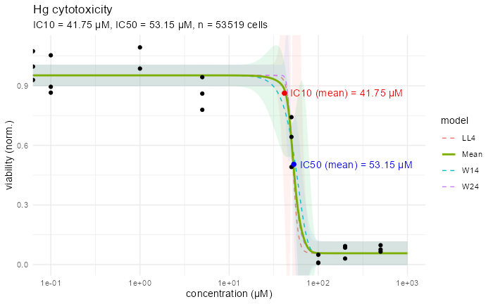

```r
y_IC10_mean <- max(dosefit_3mods$mean.Prediction) - 0.1*(max(dosefit_3mods$mean.Prediction) -  min(dosefit_3mods$mean.Prediction)) # calculates the mean viability at IC10
y_IC50_mean <- max(dosefit_3mods$mean.Prediction) - 0.5*(max(dosefit_3mods$mean.Prediction) -  min(dosefit_3mods$mean.Prediction)) # calculates the mean viability at IC50

p9 <- ggplot() +

  geom_ribbon(data = filter(dosefit_3mods, conc <= 1000), aes(x = conc, y = Prediction.LL4, ymin = Lower.LL4, ymax = Upper.LL4, fill = "LL4"), alpha = 0.1, linetype = "dashed") +
  geom_line(data = filter(dosefit_3mods, conc <= 1000), aes(conc, Prediction.LL4, color = "LL4"), size =0.5, linetype = "dashed") +

  geom_ribbon(data = filter(dosefit_3mods, conc <= 1000), aes(x = conc, y = Prediction.W14, ymin = Lower.W14, ymax = Upper.W14, fill = "W14"), alpha = 0.1, linetype = "dashed") +
  geom_line(data = filter(dosefit_3mods, conc <= 1000), aes(conc, Prediction.W14, color = "W14"), linetype = "dashed", size =0.5) +

  geom_ribbon(data = filter(dosefit_3mods, conc <= 1000), aes(x = conc, y = Prediction.W24, ymin = Lower.W24, ymax = Upper.W24, fill = "W24"), alpha = 0.1, linetype = "dashed") +
  geom_line(data = filter(dosefit_3mods, conc <= 1000), aes(conc, Prediction.W24, color = "W24"), linetype = "dashed", size =0.5) +

  geom_line(data = filter(dosefit_3mods, conc <= 1000), aes(conc, mean.Prediction, color = "Mean"), size =1) +

  geom_point(data = mean_viab_conc_replicate, aes(conc, relative_viability)) +

  geom_point(aes(x = IC_10_mean, y = y_IC10_mean), color = "red2", size = 2) +
  geom_text(aes(x = IC_10_mean, y = y_IC10_mean), label = paste("IC10 (mean) =", IC_10_mean, "µM"), nudge_x = 0.7, color = "red2") +
  geom_point(aes(x = IC_50_mean, y = y_IC50_mean), color = "blue2", size = 2) +
  geom_text(aes(x = IC_50_mean, y = y_IC50_mean), label = paste("IC50 (mean) =", IC_50_mean, "µM"), nudge_x = 0.7, color = "blue2") +

  scale_color_discrete(name = "model") +

  guides(fill="none") +

  labs(x = "concentration (µM)", y = "viability (norm.)") +

  theme_minimal() +

  scale_x_log10() +

  labs(title = "Hg cytotoxicity", subtitle = paste("IC10 =", IC_10_mean, "µM,", "IC50 =", IC_50_mean, "µM,", "n =", n_cells, "cells")) +

  coord_cartesian(ylim=c(0,1.1)) # recenters the plot. In Rstudio Options, you need to switch the graphics backends to AGG otherwise the ribbons will disappear!!!
p9
ggsave("p9_Hg_cytotox_curve_3models.pdf", plot=p9, device = "pdf", width = 7, height = 5, unit="in")
```

# 26 ———-

# 27 Dose-response curves and fit for absolute (raw) viability, without normalization to the mean of 3 measurements at 0 µM

## 27.1 Comparison of the 3 models

```r
model.LL4.raw<- drm(mean_viability~conc, data=mean_viab_conc_replicate, fct=LL.4(fixed=c(NA, NA, NA, NA), names = c("Slope", "Lower Limit", "Upper Limit", "ED50")))
mselect(model.LL4.raw, fctList = list(W1.4(fixed=c(NA, NA, NA, NA)), W2.4(fixed=c(NA, NA, NA, NA))),linreg=TRUE)
```

```
         logLik         IC Lack of fit     Res var
W1.4  35.978633 -61.957266   0.1038819 0.003102960
W2.4  35.955878 -61.911756   0.1025937 0.003109106
LL.4  35.950175 -61.900350   0.1022732 0.003110649
Cubic 29.096154 -48.192308          NA 0.005645355
Quad  22.473356 -36.946713          NA 0.009539445
Lin    5.606957  -5.213913          NA 0.039381200
```

## 27.2 Plot for models LL4, W14 and W24

```r
model.LL4.raw <-  drm(mean_viability~conc, data=mean_viab_conc_replicate, fct=LL.4(fixed=c(NA, NA, NA, NA), names = c("Slope", "Lower Limit", "Upper Limit", "ED50")))
model.W14.raw <-  drm(mean_viability~conc, data=mean_viab_conc_replicate, fct=W1.4(fixed=c(NA, NA, NA, NA), names = c("Slope", "Lower Limit", "Upper Limit", "ED50")))

model.W24.raw <-  drm(mean_viability~conc, data=mean_viab_conc_replicate, fct=W2.4(fixed=c(NA, NA, NA, NA), names = c("Slope", "Lower Limit", "Upper Limit", "ED50")))

plot(model.LL4.raw, broken = TRUE, xlab="Concentration (µM), LL4(black), W14(red), W24(green) ", ylab="viability", type='all',lty=1, lwd=2,)

plot(model.W14.raw, add = TRUE, col="red2",lty=2, lwd=2)
```

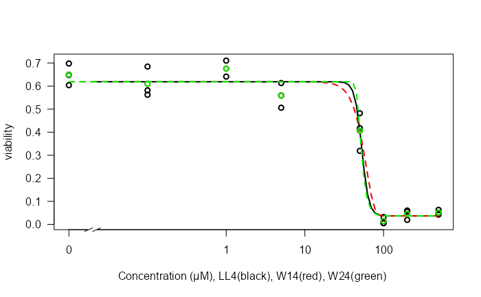

```r
plot(model.W24.raw, add = TRUE, col="green2",lty=2, lwd=2)
```

## 27.3 Calculation of IC10 and IC50 for absolute viability, weighted mean for the three models LL4, W14 and W24

```r
maED(model.LL4.raw, list(W1.4(fixed=c(NA, NA, NA, NA)), W2.4(fixed=c(NA, NA, NA, NA))),c(10, 50), interval="kang")
```

```
         ED10     ED50    Weight
LL.4 42.25541 52.90244 0.3295342
W1.4 35.34695 55.25804 0.3390469
W2.4 45.73519 52.05246 0.3314190

       Estimate    Lower    Upper
e:1:10 41.06639 25.82903 56.30374
e:1:50 53.41940 45.93424 60.90456
```

```r
capture.output(maED(model.LL4.raw, list(W1.4(fixed=c(NA, NA, NA, NA)), W2.4(fixed=c(NA, NA, NA, NA))),c(10, 50), interval="kang"), file ="IC10_IC50_mean_output_R_raw.txt")

IC_mean_model_raw <- as_tibble(maED(model.LL4.raw, list(W1.4(fixed=c(NA, NA, NA, NA)), W2.4(fixed=c(NA, NA, NA, NA))),c(10, 50), interval="kang", display = FALSE), rownames = NA) %>% rownames_to_column(var = "IC_mean") %>% separate(IC_mean, sep=":", into=c("A", "B", "IC_mean")) %>% dplyr::select(-A, -B) %>% mutate(IC_mean = as.numeric(IC_mean))

IC_10_mean_raw <- round(filter(IC_mean_model_raw, IC_mean == 10)$Estimate, 2)
IC_50_mean_raw <- round(filter(IC_mean_model_raw, IC_mean == 50)$Estimate, 2)

IC_mean_model_raw
```

| IC_mean | Estimate | Lower | Upper |
| --- | --- | --- | --- |
| 10 | 41.06639 | 25.82903 | 56.30374 |
| 50 | 53.41940 | 45.93424 | 60.90456 |

```r
write_csv(file = "IC_mean_model_R_raw.csv", IC_mean_model_raw)
```

## 27.4 Plot of the 3 models three models LL4, W14 and W24 with absolute viabilities, without normalsiation at 0 µM, with ggplot2 (see paper by Ritz et al. Dose-response Analysis Using R, PLOS ONE 2015, in the supplementary)

The drc::predict function is used to calculate the coordinates of the points over the chosen concentration range

### 27.4.1 Data preparation

```r
# creation of the extended concentration range: must be a dataframe
newdata3 <- data.frame(conc = seq(0, 10000, length=100000)) # variable conc from 0 to 10000 in steps of 0.1

# calculation based on LL4, W14 and W24 models
predmod.LL4.raw <- predict(model.LL4.raw, newdata = newdata3, interval="confidence")
predmod.W14.raw <- predict(model.W14.raw, newdata = newdata3, interval="confidence")
predmod.W24.raw <- predict(model.W24.raw, newdata = newdata3, interval="confidence")
```

```r
# conversion of dataframes into tibbles for easier merging and manipulation

newdata3 <- as_tibble(newdata3)

predmod.LL4.raw <- as_tibble(predmod.LL4.raw)
predmod.LL4.raw <- predmod.LL4.raw %>% rename(Prediction.LL4.raw = Prediction, Lower.LL4.raw = Lower, Upper.LL4.raw = Upper)

predmod.W14.raw <- as_tibble(predmod.W14.raw)
predmod.W14.raw <- predmod.W14.raw %>% rename(Prediction.W14.raw = Prediction, Lower.W14.raw = Lower, Upper.W14.raw = Upper)

predmod.W24.raw <- as_tibble(predmod.W24.raw)
predmod.W24.raw <- predmod.W24.raw %>% rename(Prediction.W24.raw = Prediction, Lower.W24.raw = Lower, Upper.W24.raw = Upper)

# merging the four tables
dosefit_3mods_raw <-bind_cols(newdata3, predmod.LL4.raw, predmod.W14.raw, predmod.W24.raw)

# Calculation of the mean of the 3 curves
dosefit_3mods_raw <- dosefit_3mods_raw %>% rowwise %>% mutate(mean.Prediction = mean(c(Prediction.LL4.raw, Prediction.W14.raw, Prediction.W24.raw)))
head(dosefit_3mods_raw)
```

| conc | Prediction.LL4.raw | Lower.LL4.raw | Upper.LL4.raw | Prediction.W14.raw | Lower.W14.raw | Upper.W14.raw | Prediction.W24.raw | Lower.W24.raw | Upper.W24.raw | mean.Prediction |
| --- | --- | --- | --- | --- | --- | --- | --- | --- | --- | --- |
| 0.000000 | 0.6189534 | 0.5837578 | 0.6541489 | 0.6190064 | 0.5838511 | 0.6541617 | 0.6189829 | 0.5837952 | 0.6541705 | 0.6189809 |
| 0.100001 | 0.6189534 | 0.5837578 | 0.6541489 | 0.6190064 | 0.5838511 | 0.6541617 | 0.6189829 | 0.5837952 | 0.6541705 | 0.6189809 |
| 0.200002 | 0.6189534 | 0.5837578 | 0.6541489 | 0.6190064 | 0.5838511 | 0.6541617 | 0.6189829 | 0.5837952 | 0.6541705 | 0.6189809 |
| 0.300003 | 0.6189534 | 0.5837578 | 0.6541489 | 0.6190064 | 0.5838511 | 0.6541617 | 0.6189829 | 0.5837952 | 0.6541705 | 0.6189809 |
| 0.400004 | 0.6189534 | 0.5837578 | 0.6541489 | 0.6190064 | 0.5838511 | 0.6541617 | 0.6189829 | 0.5837952 | 0.6541705 | 0.6189809 |
| 0.500005 | 0.6189534 | 0.5837578 | 0.6541489 | 0.6190064 | 0.5838511 | 0.6541617 | 0.6189829 | 0.5837952 | 0.6541705 | 0.6189809 |

### 27.4.2 Plot of the 3 curves

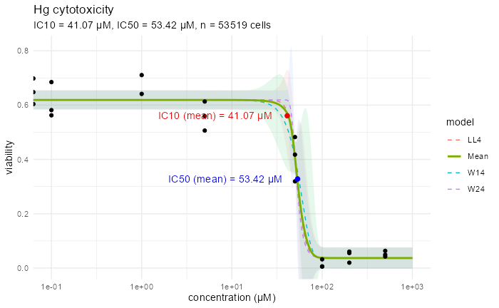

```r
y_IC10_mean_raw <- max(dosefit_3mods_raw$mean.Prediction) - 0.1*(max(dosefit_3mods_raw$mean.Prediction) -  min(dosefit_3mods_raw$mean.Prediction)) # calculates mean viability at IC10
y_IC50_mean_raw <- max(dosefit_3mods_raw$mean.Prediction) - 0.5*(max(dosefit_3mods_raw$mean.Prediction) -  min(dosefit_3mods_raw$mean.Prediction)) # calculates average viability at IC50

p10 <- ggplot() +

  geom_ribbon(data = filter(dosefit_3mods_raw, conc <= 1000), aes(x = conc, y = Prediction.LL4.raw, ymin = Lower.LL4.raw, ymax = Upper.LL4.raw, fill = "LL4"), alpha = 0.1, linetype = "dashed") +
  geom_line(data = filter(dosefit_3mods_raw, conc <= 1000), aes(conc, Prediction.LL4.raw, color = "LL4"), size =0.5, linetype = "dashed") +

  geom_ribbon(data = filter(dosefit_3mods_raw, conc <= 1000), aes(x = conc, y = Prediction.W14.raw, ymin = Lower.W14.raw, ymax = Upper.W14.raw, fill = "W14"), alpha = 0.1, linetype = "dashed") +
  geom_line(data = filter(dosefit_3mods_raw, conc <= 1000), aes(conc, Prediction.W14.raw, color = "W14"), linetype = "dashed", size =0.5) +

  geom_ribbon(data = filter(dosefit_3mods_raw, conc <= 1000), aes(x = conc, y = Prediction.W24.raw, ymin = Lower.W24.raw, ymax = Upper.W24.raw, fill = "W24"), alpha = 0.1, linetype = "dashed") +
  geom_line(data = filter(dosefit_3mods_raw, conc <= 1000), aes(conc, Prediction.W24.raw, color = "W24"), linetype = "dashed", size =0.5) +

  geom_line(data = filter(dosefit_3mods_raw, conc <= 1000), aes(conc, mean.Prediction, color = "Mean"), size =1) +

  geom_point(data = mean_viab_conc_replicate, aes(conc, mean_viability)) +

  geom_point(aes(x = IC_10_mean_raw, y = y_IC10_mean_raw), color = "red2", size = 2) +
  geom_text(aes(x = IC_10_mean_raw, y = y_IC10_mean_raw), label = paste("IC10 (mean) =", IC_10_mean_raw, "µM"), nudge_x = -0.8, color = "red2") +
  geom_point(aes(x = IC_50_mean_raw, y = y_IC50_mean_raw), color = "blue2", size = 2) +
  geom_text(aes(x = IC_50_mean_raw, y = y_IC50_mean_raw), label = paste("IC50 (mean) =", IC_50_mean_raw, "µM"), nudge_x = -0.8, color = "blue2") +

  scale_color_discrete(name = "model") +

  guides(fill="none") +

  labs(x = "concentration (µM)", y = "viability") +

  theme_minimal() +

  scale_x_log10() +

  labs(title = "Hg cytotoxicity", subtitle = paste("IC10 =", IC_10_mean_raw, "µM,", "IC50 =", IC_50_mean_raw, "µM,", "n =", n_cells, "cells")) +

   coord_cartesian(ylim=c(0,NA))
p10
ggsave("p10_Hg_cytotox_curve_3models_raw.pdf", plot=p10, device = "pdf", width = 7, height = 5, unit="in")
```